# Kontrolltöö 1

Veronica Vinkler

2025-03-27

# Ülesanded

## A) Lugege andmestik R-i.

Loeme andmestiku Nutritional_kt1 csv abil.

## B) Kontrollige andmestiku struktuuri funktsiooni str() abil. Mitu objekti ja mitu tunnust on andmestikus?

```r
str(nuti)
```

```
## 'data.frame':    127 obs. of  15 variables:
##  $ Location     : chr  "BurgerKing" "BurgerKing" "BurgerKing" "BurgerKing" ...
##  $ ItemName     : chr  "Whopper" "Whopperw/Cheese" "DoubleWhopper" "DoubleWhopperw/Cheese" ...
##  $ Type         : chr  "Beef" "Beef" "Beef" "Beef" ...
##  $ Calories     : int  640 730 870 960 420 460 330 380 600 640 ...
##  $ FatCalories  : int  350 410 500 570 220 250 140 170 320 350 ...
##  $ TotalFat     : int  39 46 56 63 24 28 15 19 36 39 ...
##  $ SaturatedFat : int  14 30 25 30 7 9 5 8 15 17 ...
##  $ Cholesterol  : int  90 115 170 195 60 75 55 65 135 145 ...
##  $ Sodium       : int  870 1350 940 1420 530 770 530 770 1060 1240 ...
##  $ Carbohydrates: int  45 46 45 46 29 29 28 28 28 28 ...
##  $ Fiber        : int  3 3 3 3 2 2 1 1 1 1 ...
##  $ Sugar        : int  8 8 8 8 5 5 4 5 5 5 ...
##  $ Protein      : int  27 33 46 52 21 23 20 23 41 44 ...
##  $ PercentCalFat: num  54.7 56.2 57.5 59.4 52.4 ...
##  $ PercentSatFat: num  35.9 65.2 44.6 47.6 29.2 ...
```

Antud andmestikus on 127 objekti ja 15 tunnust.

## C) Tehke andmestikust ülevaade dfsummary() või skim() funktsiooni abil. Mitu arvulist ja mitu mittearvulist tunnust andmestikus on?

```r
library(skimr)
skim(nuti)
```

Data summary

| Name | nuti |
| --- | --- |
| Number of rows | 127 |
| Number of columns | 15 |
| _______________________ |  |
| Column type frequency: |  |
| character | 3 |
| numeric | 12 |
| ________________________ |  |
| Group variables | None |

**Variable type: character**

| skim_variable | n_missing | complete_rate | min | max | empty | n_unique | whitespace |
| --- | --- | --- | --- | --- | --- | --- | --- |
| Location | 0 | 1 | 3 | 10 | 0 | 4 | 0 |
| ItemName | 0 | 1 | 4 | 33 | 0 | 125 | 0 |
| Type | 0 | 1 | 3 | 9 | 0 | 8 | 0 |

**Variable type: numeric**

| skim_variable | n_missing | complete_rate | mean | sd | p0 | p25 | p50 | p75 | p100 | hist |
| --- | --- | --- | --- | --- | --- | --- | --- | --- | --- | --- |
| Calories | 0 | 1 | 367.37 | 185.23 | 45.00 | 220.00 | 330.00 | 470.00 | 960.00 | ▅▇▅▂▁ |
| FatCalories | 0 | 1 | 167.90 | 118.75 | 5.00 | 70.00 | 140.00 | 240.00 | 570.00 | ▇▇▃▂▁ |
| TotalFat | 0 | 1 | 18.78 | 13.24 | 1.00 | 8.00 | 16.00 | 27.00 | 63.00 | ▇▆▃▂▁ |
| SaturatedFat | 0 | 1 | 5.81 | 5.03 | 0.00 | 2.00 | 5.00 | 8.00 | 30.00 | ▇▃▁▁▁ |
| Cholesterol | 0 | 1 | 56.12 | 57.61 | 0.00 | 20.00 | 50.00 | 70.00 | 405.00 | ▇▁▁▁▁ |
| Sodium | 0 | 1 | 897.89 | 456.79 | 0.00 | 530.00 | 890.00 | 1225.00 | 2230.00 | ▅▇▇▃▁ |
| Carbohydrates | 0 | 1 | 32.43 | 16.57 | 4.00 | 17.50 | 35.00 | 46.00 | 77.00 | ▆▅▇▂▁ |
| Fiber | 0 | 1 | 2.35 | 1.72 | 0.00 | 1.00 | 2.00 | 4.00 | 7.00 | ▇▃▇▁▁ |
| Sugar | 0 | 1 | 5.72 | 7.89 | 0.00 | 0.00 | 4.00 | 7.00 | 50.00 | ▇▁▁▁▁ |
| Protein | 0 | 1 | 17.56 | 10.71 | 1.00 | 9.00 | 18.00 | 24.00 | 52.00 | ▇▇▇▂▁ |
| PercentCalFat | 0 | 1 | 42.25 | 15.21 | 4.35 | 33.74 | 45.00 | 54.03 | 68.33 | ▂▁▅▇▃ |
| PercentSatFat | 0 | 1 | 32.19 | 14.50 | 0.00 | 23.21 | 31.25 | 40.00 | 100.00 | ▂▇▂▁▁ |

## D) Kas andmestikus on duplikaadid? Mitu neid on? Eemaldage duplikaadid andmestikust.

```r
sum(duplicated(nuti))
```

```
## [1] 0
```

Antud andmestikus ei leidu duplikaate.

## E) Kas andmestikus on puuduvate väärtustega objektid? Mitu neid on? Eemaldage andmestikust puuduvate väärtusega objektid.

Kontrollime kas andmestikus on puuduvate väätustega ridasid.

```r
sum(!complete.cases(nuti))
```

```
## [1] 0
```

## F) Kontrollige, et andmetüübid on R-i poolt õigesti loetud, vajadusel tehke parandusi. Muutke mittearvuliste tunnuste tüübid factor-tüübiks. Tehke uuendatud andmestikust ülevaade dfsummary() või skim() abil. Tehke järeldused andmestiku struktuuri kohta

```r
nuti <- as.data.frame(unclass(nuti), stringAsFactors = TRUE)
```

Nüüd loome ülevaate.

```r
skim(nuti)
```

Data summary

| Name | nuti |
| --- | --- |
| Number of rows | 127 |
| Number of columns | 15 |
| _______________________ |  |
| Column type frequency: |  |
| character | 3 |
| numeric | 12 |
| ________________________ |  |
| Group variables | None |

**Variable type: character**

| skim_variable | n_missing | complete_rate | min | max | empty | n_unique | whitespace |
| --- | --- | --- | --- | --- | --- | --- | --- |
| Location | 0 | 1 | 3 | 10 | 0 | 4 | 0 |
| ItemName | 0 | 1 | 4 | 33 | 0 | 125 | 0 |
| Type | 0 | 1 | 3 | 9 | 0 | 8 | 0 |

**Variable type: numeric**

| skim_variable | n_missing | complete_rate | mean | sd | p0 | p25 | p50 | p75 | p100 | hist |
| --- | --- | --- | --- | --- | --- | --- | --- | --- | --- | --- |
| Calories | 0 | 1 | 367.37 | 185.23 | 45.00 | 220.00 | 330.00 | 470.00 | 960.00 | ▅▇▅▂▁ |
| FatCalories | 0 | 1 | 167.90 | 118.75 | 5.00 | 70.00 | 140.00 | 240.00 | 570.00 | ▇▇▃▂▁ |
| TotalFat | 0 | 1 | 18.78 | 13.24 | 1.00 | 8.00 | 16.00 | 27.00 | 63.00 | ▇▆▃▂▁ |
| SaturatedFat | 0 | 1 | 5.81 | 5.03 | 0.00 | 2.00 | 5.00 | 8.00 | 30.00 | ▇▃▁▁▁ |
| Cholesterol | 0 | 1 | 56.12 | 57.61 | 0.00 | 20.00 | 50.00 | 70.00 | 405.00 | ▇▁▁▁▁ |
| Sodium | 0 | 1 | 897.89 | 456.79 | 0.00 | 530.00 | 890.00 | 1225.00 | 2230.00 | ▅▇▇▃▁ |
| Carbohydrates | 0 | 1 | 32.43 | 16.57 | 4.00 | 17.50 | 35.00 | 46.00 | 77.00 | ▆▅▇▂▁ |
| Fiber | 0 | 1 | 2.35 | 1.72 | 0.00 | 1.00 | 2.00 | 4.00 | 7.00 | ▇▃▇▁▁ |
| Sugar | 0 | 1 | 5.72 | 7.89 | 0.00 | 0.00 | 4.00 | 7.00 | 50.00 | ▇▁▁▁▁ |
| Protein | 0 | 1 | 17.56 | 10.71 | 1.00 | 9.00 | 18.00 | 24.00 | 52.00 | ▇▇▇▂▁ |
| PercentCalFat | 0 | 1 | 42.25 | 15.21 | 4.35 | 33.74 | 45.00 | 54.03 | 68.33 | ▂▁▅▇▃ |
| PercentSatFat | 0 | 1 | 32.19 | 14.50 | 0.00 | 23.21 | 31.25 | 40.00 | 100.00 | ▂▇▂▁▁ |

# Järgnevad ülesanded täidetakse Teie variandile vastavate tunnustega.

Edasi teen tööd väärtustega Percent CalFat ja Location.

## Määrake oma arvulise tunnuse tüüp (kas pidev või diskreetne või diskreetne palju erinevate väärtustega) Oma arvulise tunnuse jaoks konstrueerige ja vormistage korrektselt suhteliste sageduste tulpdiagramm ja karpdiagramm. Tehke erindite analüüs.

### Suhteliste sageduse Tulpdiagramm

Tunnuse PercentCalFat suhteliste sageduste histogramm ja karpdiagramm:

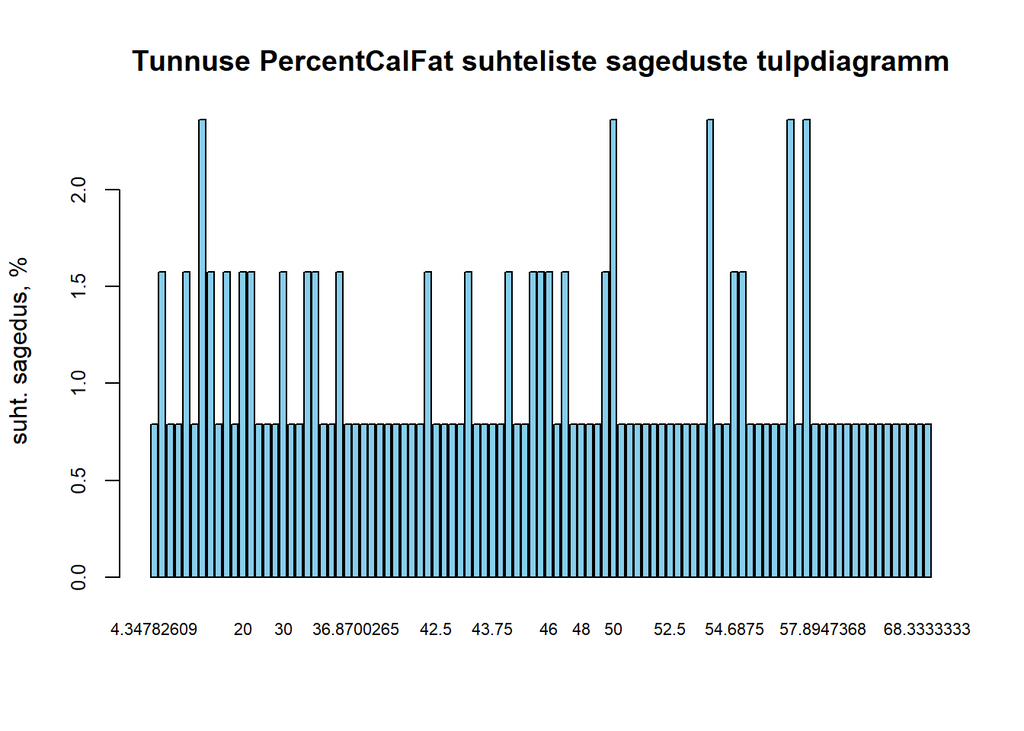

```r
barplot(prop.table(table(nuti$PercentCalFat))*100, col = "skyblue", cex.names = 0.7, cex.axis = 0.8, main = "Tunnuse PercentCalFat suhteliste sageduste tulpdiagramm", ylab = "suht. sagedus, %")
```

### Suhtelise sageduse Karpdiagramm

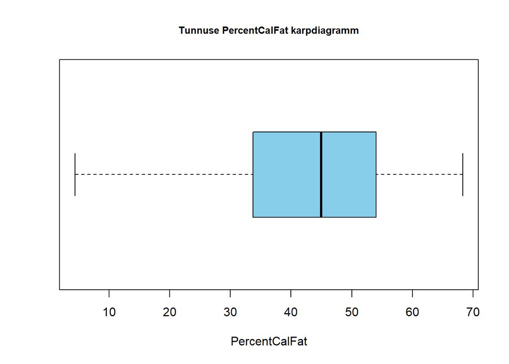

```r
b <- boxplot(nuti$PercentCalFat, col = "skyblue", horizontal = 1, main="Tunnuse PercentCalFat karpdiagramm",xlab="PercentCalFat",cex.main=0.8, range = 3)
```

## H) Oma arvulise tunnuse jaoks tehke sagedustabel, milles peavad olema esitatud sagedused, suhtelised sagedused %-des ja kumuleeritud suhtelised sagedused %-des

Tunnuse PercentCalFat sagedustabel:

```r
intervallid <-cut(nuti$PercentCalFat,seq(1,100,by=2),include.lowest = TRUE)
sagedus <- table(intervallid)
suht.sagedus <-prop.table(table(intervallid))*100
sagedustabel <- cbind(rownames(sagedus),sagedus,round(suht.sagedus,2),round(cumsum(suht.sagedus),2))
sagedustabel <- data.frame(sagedustabel,row.names = NULL)
sagedustabel <-rbind(sagedustabel,c("Total",sum(sagedus),sum(suht.sagedus),""))
names(sagedustabel) <- c("PercentCalFat","sagedus","suht.sagedus,%","kum.suht.sagedus,%")

library(knitr)
library(kableExtra)

kable_styling(kable(sagedustabel,align = c('l','r','r','r')),bootstrap_options = c("striped","hover"),full_width = 0,position = "left")
```

| PercentCalFat | sagedus | suht.sagedus,% | kum.suht.sagedus,% |
| --- | --- | --- | --- |
| [1,3] | 0 | 0 | 0 |
| (3,5] | 1 | 0.79 | 0.79 |
| (5,7] | 2 | 1.57 | 2.36 |
| (7,9] | 0 | 0 | 2.36 |
| (9,11] | 0 | 0 | 2.36 |
| (11,13] | 1 | 0.79 | 3.15 |
| (13,15] | 4 | 3.15 | 6.3 |
| (15,17] | 8 | 6.3 | 12.6 |
| (17,19] | 1 | 0.79 | 13.39 |
| (19,21] | 4 | 3.15 | 16.54 |
| (21,23] | 2 | 1.57 | 18.11 |
| (23,25] | 1 | 0.79 | 18.9 |
| (25,27] | 0 | 0 | 18.9 |
| (27,29] | 0 | 0 | 18.9 |
| (29,31] | 3 | 2.36 | 21.26 |
| (31,33] | 3 | 2.36 | 23.62 |
| (33,35] | 3 | 2.36 | 25.98 |
| (35,37] | 5 | 3.94 | 29.92 |
| (37,39] | 1 | 0.79 | 30.71 |
| (39,41] | 4 | 3.15 | 33.86 |
| (41,43] | 11 | 8.66 | 42.52 |
| (43,45] | 10 | 7.87 | 50.39 |
| (45,47] | 5 | 3.94 | 54.33 |
| (47,49] | 8 | 6.3 | 60.63 |
| (49,51] | 5 | 3.94 | 64.57 |
| (51,53] | 8 | 6.3 | 70.87 |
| (53,55] | 11 | 8.66 | 79.53 |
| (55,57] | 8 | 6.3 | 85.83 |
| (57,59] | 9 | 7.09 | 92.91 |
| (59,61] | 4 | 3.15 | 96.06 |
| (61,63] | 2 | 1.57 | 97.64 |
| (63,65] | 2 | 1.57 | 99.21 |
| (65,67] | 0 | 0 | 99.21 |
| (67,69] | 1 | 0.79 | 100 |
| (69,71] | 0 | 0 | 100 |
| (71,73] | 0 | 0 | 100 |
| (73,75] | 0 | 0 | 100 |
| (75,77] | 0 | 0 | 100 |
| (77,79] | 0 | 0 | 100 |
| (79,81] | 0 | 0 | 100 |
| (81,83] | 0 | 0 | 100 |
| (83,85] | 0 | 0 | 100 |
| (85,87] | 0 | 0 | 100 |
| (87,89] | 0 | 0 | 100 |
| (89,91] | 0 | 0 | 100 |
| (91,93] | 0 | 0 | 100 |
| (93,95] | 0 | 0 | 100 |
| (95,97] | 0 | 0 | 100 |
| (97,99] | 0 | 0 | 100 |
| Total | 127 | 100 |  |

## I) Oma arvulise tunnuse jaoks arvutage välja kõik võimalikud arvkarakteristikud.

Tunnuse PercentCalFat arvkarakteristikud:

```r
library(FSA)
arvkar <- Summarize(nuti$PercentCalFat, digits = 2)
kable_styling(kable(t(arvkar)))
```

| n | mean | sd | min | Q1 | median | Q3 | max |
| --- | --- | --- | --- | --- | --- | --- | --- |
| 127 | 42.25 | 15.21 | 4.35 | 33.74 | 45 | 54.03 | 68.33 |